# Izvješće o analizi troškova potrošnje električne energije s ciljem optimizacije i povećanja udjela električne energije

Antonio Labinjan

## 1. Opći podatci:

1.1. Naručitelj analize: Neimenovano poduzeće koje želi optimizirati troškove potrošnje električne energije i povećati udio obnovljivih izvora energije.

1.2. Datum narudžbe analize: 3. prosinac 2024.

1.3. Rok predaje analize: 10. prosinac 2024.

1.4. Razlog i cilj analize:

Analiza se provodi zato što poduzeće trenutno svu električnu energiju kupuje od lokalnog distributera te želi ispitati mogućnost uvođenja alternativnih izvora energije. Također, poduzeće želi provesti usklađivanje s ciljevima Europske komisije o povećanju udjela energije iz obnovljivih izvora. Cilj analize je pronaći optimalnu kombinaciju izvora energije koja osigurava najmanji mogući mjesečni trošak, uz zadovoljavanje svih tehničkih i financijskih ograničenja.

## 2. Opis postupka provedbe analize

2.1. Osnovni ciljevi i zadatci analize:

Poduzeće ima više kriterija koje želi zadovoljiti. Žele slijedeće: - Osigurati minimalni mjesečni trošak za električnu energiju kako bi uštedjeli financijske resurse i imali više sredstava za ulaganje u druga područja. - Povećati udio obnovljivih izvora energije na najmanje 30 % ukupnih potreba kako bi povećali isplativost i smanjili negativan utjecaj na okoliš. - Zadovoljiti mjesečnu potražnju poduzeća za 100 kW energije kako bi mogli nastaviti s normalnim radom prema predviđenim planovima. - Ograničiti trošak instalacije na budžet od 215.000 € kako ne bi na optimiziranje energetskih resursa potrošili previše i tako onemogućili izvedbu ostalih projekata.

2.2. Kriteriji evaluacija alternativa

Pošto se radi o složenijoj analizi koja ne ovisi o samo jednom faktoru, potrebno je problem promotriti kroz više gledišta: - Financijsku održivost – zadovoljenje ograničenja budžeta - Postotak obnovljivih izvora energije - Minimalizaciju ukupnih mjesečnih troškova

Potrebno je što je bolje moguće izbalansirati sva 3 elementa kako bi poduzeće došlo do optimalnog rješenja koje će zadovoljiti financijska ograničenja, minimizirati troškove i upotrebljavati dovoljno obnovljivih izvora kako bi bilo ekološki održivo.

2.3. Koraci u provođenju analize

Analiza se provodila kroz više koraka kako bi se osiguralo da je svaki element optimiziran i da se odabere najbolja alternativa u svakom dijelu odlučivanja.

Najprije je bilo potrebno definirati koje su sve dostupne alternative i nakon istraživanja utvrđeno je da su to: - solarne elektrane - vjetroturbine - lokalni distributeri Također, utvrđeno je da postoje 2 vrste solarnih elektrana (od 10 kW i 30 kW).

Nakon definiranja alternativa, bilo je potrebno detaljnije evaluirati svaku od njih. Kako se radi o sličnim rješenjima, bilo ih je moguće evaluirati po istim kriterijima. Dakle, za sve 4 alternative, definirani su sljedeći kriteriji: - Dostupnost električne energije mjesečno (u KW) - Cijena postavljanja - Mjesečni trošak po kW - Fiksni dio mjesečnog troška

Zatim se provela evaluacija kriterija u skladu s definiranim ciljevima i ograničenjima.

2.4. Korištene metode

Donesena je odluka o evaluaciji korištenjem programskog jezika R, konkretnije korištene su metode cjelobrojnog linearnog programiranja jer omogućuju rješavanje optimizacijskih problema s ograničenjima koja uključuju cjelobrojne i kontinuirane varijable. U konkretnom slučaju, metoda je bila idealna za modeliranje ograničenja poput budžeta, udjela obnovljivih izvora i ukupne potrošnje energije, uz istovremenu minimizaciju troškova.

## 3. Rezultati

3.1. Struktura problema

Do varijabli odluke došlo se proučavanjem samog problema i utvrđivanjem faktora koji se mogu mijenjati na temelju donesene odluke.

**Funkcija cilja:**  
Cilj je minimizirati ukupne troškove proizvodnje energije koristeći troškove koje svaka varijabla odluke nosi i uzimajući u obzir količinu svake varijable:  
43.51 $x_1$ + 79,050 $x_2$ + 195,060 $x_3$ + 8,040 $x_4$ + 55.03

**Ograničenja:**  
Ograničenja su definirana promatrajući uvjete problema odnosno limite unutar kojih se ciljne vrijednosti smiju, odnosno moraju nalaziti: 1. Ukupna energija proizvedena iz obnovljivih izvora mora biti najmanje 30 kWh:  
10 $x_2$ + 30 $x_3$ + $x_4$ ≥ 30  
2. Ukupna proizvedena energija mora zadovoljiti minimalnu potrebnu potrošnju od 100 kWh:  
$x_1$ + 10 $x_2$ + 30 $x_3$ + $x_4$ ≥ 100  
3. Trošak instalacije mora biti unutar budžeta od 215,000 kuna:  
79,000 $x_2$ + 195,000 $x_3$ + 8,000 $x_4$ ≤ 215,000

3.2. Prikaz provedene analize (prikaz rješavanja)

3.2.1. Računski pristup Napomena: namjerno su ostavljeni komentari na vrhu koda pošto su mi značajno pomogli u rješavanju i olakšali mi setup problema te ih se može smatrati integralnim dijelom koda.

```r
# SETUP => CJELOBROJNO
# VARIJABLE ODLUKE

#x1 - lokalni distributer
#x2 - solarna elektrana 10 KW
#x3 - solarna elektrana 30 KW
#x4 - vjetrotrubine

# OGRANIČENJA
# 10x2 + 30x3 + 1x4 >= 30 KW
# x1 + 10x2 + 30x3 + 1x4 >= 100 KW
# 79000 x2 + 195000 x3 + 8000 x4 <= 215000

# FUNKCIJA CILJA
# min((43.51 * x1) + ((79000+50)*x2) + ((195000+60)*x3)+((8000+40)*x4)+ 55.03)
# odnosno
# min(43.51 x1 + 79050 x2 + 195060 x3 + 8040 x4 + 55.03)

install.packages("lpSolve")
library(lpSolve)
obj <- c(43.51, 79050, 195060, 8040)


const_mat <- matrix(c(0, 10, 30, 1,   # 10x2 + 30x3 + x4 >= 30
              1, 10, 30, 1,   # x1 + 10x2 + 30x3 + x4 >= 100
              0, 79000, 195000, 8000), # 79000x2 + 195000x3 + 8000x4 <= 215000
            nrow=3, byrow=TRUE)


const_dir <- c(">=", ">=", "<=")


rhs <- c(30, 100, 215000)


rjesenje <- lp("min", obj, const_mat, const_dir, rhs, compute.sens=TRUE)


print("Optimalne vrijednosti varijabli:")
```

```
## [1] "Optimalne vrijednosti varijabli:"
```

```r
print(rjesenje$solution)
```

```
## [1] 70  0  1  0
```

```r
print(paste("Minimalni trošak:", rjesenje$objval))
```

```
## [1] "Minimalni trošak: 198105.7"
```

```r
print(rjesenje$objval)
```

```
## [1] 198105.7
```

```r
# ILI
install.packages("linprog")
library(linprog)
obj <- c(43.51, 79050, 195060, 8040)

const_mat <- matrix(c(0, 10, 30, 1,   # 10x2 + 30x3 + x4 >= 30
                      1, 10, 30, 1,   # x1 + 10x2 + 30x3 + x4 >= 100
                      0, 79000, 195000, 8000), # 79000x2 + 195000x3 + 8000x4 <= 215000
                    nrow=3, byrow=TRUE)

const_dir <- c(">=", ">=", "<=")


rhs <- c(30, 100, 215000)

rjesenje <- solveLP(cvec = obj, Amat = const_mat, bvec = rhs, maximum = FALSE, const.dir = const_dir)

print("Optimalne vrijednosti varijabli:")
```

```
## [1] "Optimalne vrijednosti varijabli:"
```

```r
print(rjesenje)
```

```
##
##
## Results of Linear Programming / Linear Optimization
##
## Objective function (Minimum): 198106
##
## Iterations in phase 1: 2
## Iterations in phase 2: 0
## Solution
##   opt
## 1  70
## 2   0
## 3   1
## 4   0
##
## Basic Variables
##       opt
## 1      70
## 3       1
## S 3 20000
##
## Constraints
##   actual dir   bvec  free    dual    dual.reg
## 1     30  >=     30     0 6458.49     3.07692
## 2    100  >=    100     0   43.51         Inf
## 3 195000  <= 215000 20000    0.00 20000.00000
##
## All Variables (including slack variables)
##       opt      cvec      min.c       max.c     marg marg.reg
## 1      70     43.51     -87.02 6.50200e+03       NA       NA
## 2       0  79050.00      99.00 7.70000e+01 14030.00  1.42857
## 3       1 195060.00 -388814.70 2.37150e+05       NA       NA
## 4       0   8040.00      99.00 7.70000e+01  1538.00 13.33333
## S 1     0      0.00   -6458.49         Inf  6458.49  3.07692
## S 2     0      0.00     -43.51         Inf    43.51      Inf
## S 3 20000      0.00         NA 9.93614e-01     0.00       NA
```

```r
print(rjesenje$solution)
```

```
##  1  2  3  4
## 70  0  1  0
```

```r
print(paste("Minimalni trošak:", rjesenje$opt))
```

```
## [1] "Minimalni trošak: 198105.7"
```

3.2.2. Grafički pristup na kojemu je moguće vidjeti koja je optimalna kombinacija izvora energije

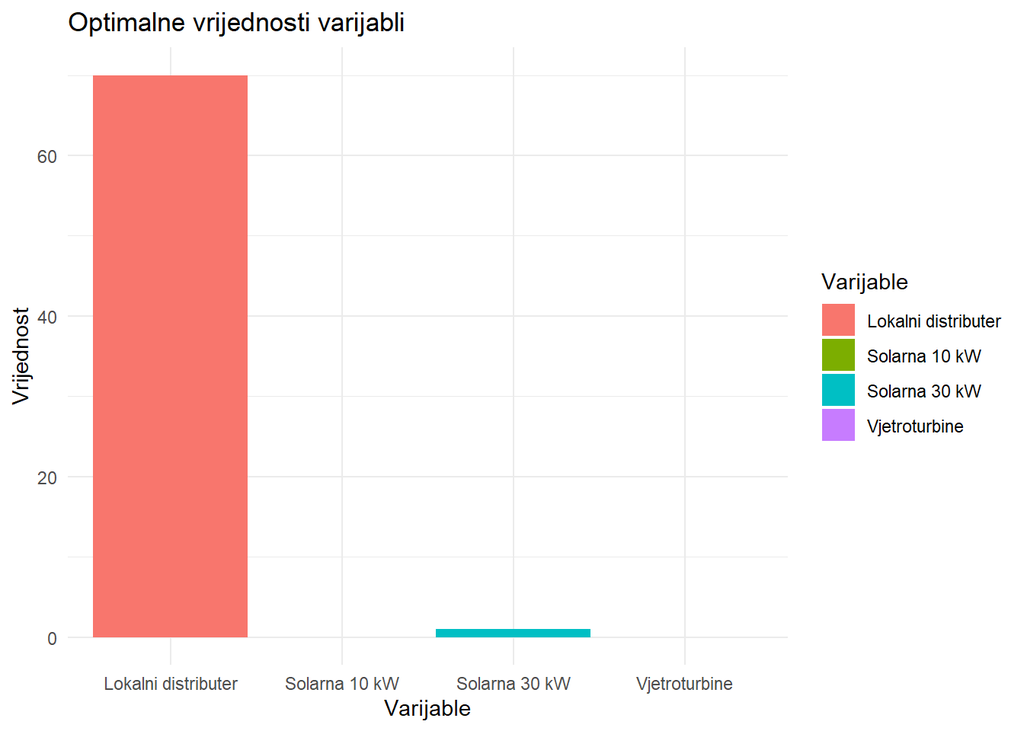

```r
install.packages("ggplot2")
library(ggplot2)
var_names <- c("Lokalni distributer", "Solarna 10 kW", "Solarna 30 kW", "Vjetroturbine")
values <- rjesenje$solution

df <- data.frame(Varijable = var_names, Vrijednosti = values)
ggplot(df, aes(x = Varijable, y = Vrijednosti, fill = Varijable)) +
  geom_bar(stat = "identity") +
  labs(title = "Optimalne vrijednosti varijabli", x = "Varijable", y = "Vrijednost") +
  theme_minimal()
```

3.3. Tumačenje dobivenih rješenja Optimalno rješenje pokazuje da je najpovoljniji način zadovoljavanja energetskih potreba korištenje lokalnog distributera za 70 kW energije te jedne solarne elektrane snage 30 kW, dok se solarne elektrane snage 10 kW i vjetroturbine uopće ne koriste zbog svojih velikih troškova.

## 4. Zaključak

Nakon provedbe analize i evaluacije rezultata, utvrđena je optimalna kombinacija izvora energije za poduzeće, te na temelju to ga može biti zaključeno da je postignut cilj optimizacije izvora energije. Svi su izvori evaluirani na temelju količine energije koju taj izvor može pružiti i cijene. Na temelju dobivenih rezultata, utvrđeno je da će se najviše koristiti lokalni distributer i da će se uz to koristiti jedna veća solarna elektrana, što je dobra odluka s obzirom na to da distributer nema troškove postavljanja, već samo omogućava da se plati onoliko koliko je potrošeno. Očekuje se optimizacija potrošnje i veća ekološka isplativost pošto je bar dio energije ipak dobiven iz obnovljivih izvora. Preporuka za budućnost je svakako dodatno istraživanje potencijalnih izvora energije kako bi se isplativost i ekološki aspekti dodatno poboljšali u budućnosti